# Myocardial Infarction (MI) Survival Analysis

# Setup Environment

```r
# turn off scientific number
options(scipen = 999)

# load libraries
library(dplyr)
library(tidyr)
library(ggplot2)
library(survival)
library(survminer)
library(ggfortify) # Hazard ratio table and plot
library(pROC) # ROC curve

# load data
library(smoothHR)
data("whas500")

# Display raw data
head(whas500)
```

|  | id | age | gender | hr | sysbp | diasbp | bmi | cvd | afb | sho | chf | av3 | miord | mitype | year | admitdate | disdate | fdate | los | dstat | lenfol | fstat |
| --- | --- | --- | --- | --- | --- | --- | --- | --- | --- | --- | --- | --- | --- | --- | --- | --- | --- | --- | --- | --- | --- | --- |
| 1 | 1 | 83 | 0 | 89 | 152 | 78 | 25.54051 | 1 | 1 | 0 | 0 | 0 | 1 | 0 | 1 | 13-01-1997 | 18-01-1997 | 31-12-2002 | 5 | 0 | 2178 | 0 |
| 2 | 2 | 49 | 0 | 84 | 120 | 60 | 24.02398 | 1 | 0 | 0 | 0 | 0 | 0 | 1 | 1 | 19-01-1997 | 24-01-1997 | 31-12-2002 | 5 | 0 | 2172 | 0 |
| 3 | 3 | 70 | 1 | 83 | 147 | 88 | 22.14290 | 0 | 0 | 0 | 0 | 0 | 0 | 1 | 1 | 01-01-1997 | 06-01-1997 | 31-12-2002 | 5 | 0 | 2190 | 0 |
| 4 | 4 | 70 | 0 | 65 | 123 | 76 | 26.63187 | 1 | 0 | 0 | 1 | 0 | 0 | 1 | 1 | 17-02-1997 | 27-02-1997 | 11-12-1997 | 10 | 0 | 297 | 1 |
| 5 | 5 | 70 | 0 | 63 | 135 | 85 | 24.41255 | 1 | 0 | 0 | 0 | 0 | 0 | 1 | 1 | 01-03-1997 | 07-03-1997 | 31-12-2002 | 6 | 0 | 2131 | 0 |
| 6 | 6 | 70 | 0 | 76 | 83 | 54 | 23.24236 | 1 | 0 | 0 | 0 | 1 | 0 | 0 | 1 | 11-03-1997 | 12-03-1997 | 12-03-1997 | 1 | 1 | 1 | 1 |

# Background

A group of researchers in the Department of Cardiology at the University of Massachusetts Medical School has collected data from 500 myocardial infarction (MI) patients from 1975 to 2001 in Worcester, Massachusetts. This project aims to identify factors associated with survival rate after hospitalization for acute MI.

- id: Patient ID
- age: Age at hospital admission in years
- gender: 0: Male / 1: Female
- hr: Initial heart rate (beats per minute)
- sysbp: Initial systolic blood pressure (mmHg)
- diasbp: Initial diastolic blood pressure (mmHg)
- bmi: Body Mass Index (kg/m2)
- cvd: History of cardiovascular disease (0: No / 1: Yes)
- afb: Atrial fibrillation (0: No / 1: Yes)
- sho: Cardiogenic shock (0: No / 1: Yes)
- chf: Congestive heart complications (0: No / 1: Yes)
- av3: Complete heart block (0: No / 1: Yes)
- miord: MI order (0: First / 1: Recurrent)
- mitype: MI type (0: Non-Q-wave / 1: Q-wave)
- admitdate: Hospital admission date (mm/dd/yyyy)
- fdate: Date of last follow-up (mm/dd/yyyy)
- los: Length of hospital stay (days from hospital admission to hospital discharge)
- fstat: Vital status at last follow-up (0: Alive / 1:Dead)

# Data Preprocessing

```r
# Check if there are any missing data
apply(whas500, 2, function(x){sum(is.na(x))})
```

```
##        id       age    gender        hr     sysbp    diasbp       bmi       cvd
##         0         0         0         0         0         0         0         0
##       afb       sho       chf       av3     miord    mitype      year admitdate
##         0         0         0         0         0         0         0         0
##   disdate     fdate       los     dstat    lenfol     fstat
##         0         0         0         0         0         0
```

```r
# Get the statistical summary and nature of the dataset
summary(whas500)
```

```
##        id             age             gender          hr
##  Min.   :  1.0   Min.   : 30.00   Min.   :0.0   Min.   : 35.00
##  1st Qu.:125.8   1st Qu.: 59.00   1st Qu.:0.0   1st Qu.: 69.00
##  Median :250.5   Median : 72.00   Median :0.0   Median : 85.00
##  Mean   :250.5   Mean   : 69.85   Mean   :0.4   Mean   : 87.02
##  3rd Qu.:375.2   3rd Qu.: 82.00   3rd Qu.:1.0   3rd Qu.:100.25
##  Max.   :500.0   Max.   :104.00   Max.   :1.0   Max.   :186.00
##
##      sysbp           diasbp            bmi             cvd
##  Min.   : 57.0   Min.   :  6.00   Min.   :13.05   Min.   :0.00
##  1st Qu.:123.0   1st Qu.: 63.00   1st Qu.:23.22   1st Qu.:0.75
##  Median :141.5   Median : 79.00   Median :25.95   Median :1.00
##  Mean   :144.7   Mean   : 78.27   Mean   :26.61   Mean   :0.75
##  3rd Qu.:164.0   3rd Qu.: 91.25   3rd Qu.:29.39   3rd Qu.:1.00
##  Max.   :244.0   Max.   :198.00   Max.   :44.84   Max.   :1.00
##
##       afb             sho             chf            av3            miord
##  Min.   :0.000   Min.   :0.000   Min.   :0.00   Min.   :0.000   Min.   :0.000
##  1st Qu.:0.000   1st Qu.:0.000   1st Qu.:0.00   1st Qu.:0.000   1st Qu.:0.000
##  Median :0.000   Median :0.000   Median :0.00   Median :0.000   Median :0.000
##  Mean   :0.156   Mean   :0.044   Mean   :0.31   Mean   :0.022   Mean   :0.342
##  3rd Qu.:0.000   3rd Qu.:0.000   3rd Qu.:1.00   3rd Qu.:0.000   3rd Qu.:1.000
##  Max.   :1.000   Max.   :1.000   Max.   :1.00   Max.   :1.000   Max.   :1.000
##
##      mitype           year            admitdate         disdate
##  Min.   :0.000   Min.   :1.000   12-10-2001:  4   12-11-2001:  4
##  1st Qu.:0.000   1st Qu.:1.000   25-10-1999:  4   03-10-2001:  3
##  Median :0.000   Median :2.000   29-06-2001:  4   04-08-1997:  3
##  Mean   :0.306   Mean   :1.984   01-08-1999:  3   06-01-1997:  3
##  3rd Qu.:1.000   3rd Qu.:3.000   02-08-1999:  3   08-06-2001:  3
##  Max.   :1.000   Max.   :3.000   04-10-1997:  3   10-11-1997:  3
##                                  (Other)   :479   (Other)   :481
##         fdate          los             dstat           lenfol
##  31-12-2002:285   Min.   : 0.000   Min.   :0.000   Min.   :   1.0
##  21-08-1999:  3   1st Qu.: 3.000   1st Qu.:0.000   1st Qu.: 296.5
##  07-12-2001:  2   Median : 5.000   Median :0.000   Median : 631.5
##  10-12-2001:  2   Mean   : 6.116   Mean   :0.078   Mean   : 882.4
##  11-12-2001:  2   3rd Qu.: 7.000   3rd Qu.:0.000   3rd Qu.:1363.5
##  12-11-2001:  2   Max.   :47.000   Max.   :1.000   Max.   :2358.0
##  (Other)   :204
##      fstat
##  Min.   :0.00
##  1st Qu.:0.00
##  Median :0.00
##  Mean   :0.43
##  3rd Qu.:1.00
##  Max.   :1.00
##
```

# Feature Engineering

```r
df <- whas500 %>%
  select(-c(year, disdate, dstat, lenfol)) %>%
  mutate(age_group = cut(age,
                         breaks=c(30,40,50,60,70,80,90,Inf),
                         labels=c("30-39","40-49","50-59","60-69","70-79","80-89","90+"),
                         include.lowest = TRUE,
                         include.highest = FALSE),
         gender = factor(gender, levels = c(0, 1), labels = c("Male", "Female")),
         hr_group = cut(hr,
                        breaks=c(30,60,90,120,150,Inf),
                        labels=c("30-59","60-89","90-119","120-149","150+"),
                        include.lowest = TRUE,
                        include.highest = FALSE),
         sysbp_group = cut(sysbp,
                           breaks=c(50,100,150,200,Inf),
                           labels=c("50-99","100-149","150-199","200+"),
                           include.lowest = TRUE,
                           include.highest = FALSE),
         diasbp_group = cut(diasbp,
                            breaks=c(0,50,70,90,110,Inf),
                            labels=c("0-49","50-69","70-89","90-109","110+"),
                            include.lowest = TRUE,
                            include.highest = FALSE),
         bmi_group = cut(bmi,
                        breaks=c(10,20,30,40,Inf),
                        labels=c("10-19","20-29","30-39","40+"),
                        include.lowest = TRUE,
                        include.highest = FALSE),
         miord = factor(miord, levels = c(0, 1), labels = c("First", "Recurrent")),
         mitype = factor(mitype, levels = c(0, 1), labels = c("Non Q-wave", "Q-wave")),
         cvd = factor(cvd, levels = c(0, 1), labels = c("No", "Yes")),
         afb = factor(afb, levels = c(0, 1), labels = c("No", "Yes")),
         chf = factor(chf, levels = c(0, 1), labels = c("No", "Yes")),
         av3 = factor(av3, levels = c(0, 1), labels = c("No", "Yes")),
         admitdate = as.Date(admitdate, format = "%d-%m-%Y"), # change the date format
         fdate = as.Date(fdate, format = "%d-%m-%Y"), # change the date format
         survival_time = as.numeric(difftime(fdate, admitdate, units = "days")) / 30.42, # new variable for survival time (month)
         censor = ifelse(((fdate - admitdate) < 365.25) & fstat == 1, 1, 0),
         status = factor(fstat, levels = c(0, 1), labels = c("Alive", "Dead"))) # identify status using new censor data

head(df)
```

|  | id | age | gender | hr | sysbp | diasbp | bmi | cvd | afb | sho | chf | av3 | miord | mitype | admitdate | fdate | los | fstat | age_group | hr_group | sysbp_group | diasbp_group | bmi_group | survival_time | censor | status |
| --- | --- | --- | --- | --- | --- | --- | --- | --- | --- | --- | --- | --- | --- | --- | --- | --- | --- | --- | --- | --- | --- | --- | --- | --- | --- | --- |
| 1 | 1 | 83 | Male | 89 | 152 | 78 | 25.54051 | Yes | Yes | 0 | No | No | Recurrent | Non Q-wave | 1997-01-13 | 2002-12-31 | 5 | 0 | 80-89 | 60-89 | 150-199 | 70-89 | 20-29 | 71.59763314 | 0 | Alive |
| 2 | 2 | 49 | Male | 84 | 120 | 60 | 24.02398 | Yes | No | 0 | No | No | First | Q-wave | 1997-01-19 | 2002-12-31 | 5 | 0 | 40-49 | 60-89 | 100-149 | 50-69 | 20-29 | 71.40039448 | 0 | Alive |
| 3 | 3 | 70 | Female | 83 | 147 | 88 | 22.14290 | No | No | 0 | No | No | First | Q-wave | 1997-01-01 | 2002-12-31 | 5 | 0 | 60-69 | 60-89 | 100-149 | 70-89 | 20-29 | 71.99211045 | 0 | Alive |
| 4 | 4 | 70 | Male | 65 | 123 | 76 | 26.63187 | Yes | No | 0 | Yes | No | First | Q-wave | 1997-02-17 | 1997-12-11 | 10 | 1 | 60-69 | 60-89 | 100-149 | 70-89 | 20-29 | 9.76331361 | 1 | Dead |
| 5 | 5 | 70 | Male | 63 | 135 | 85 | 24.41255 | Yes | No | 0 | No | No | First | Q-wave | 1997-03-01 | 2002-12-31 | 6 | 0 | 60-69 | 60-89 | 100-149 | 70-89 | 20-29 | 70.05259698 | 0 | Alive |
| 6 | 6 | 70 | Male | 76 | 83 | 54 | 23.24236 | Yes | No | 0 | No | Yes | First | Non Q-wave | 1997-03-11 | 1997-03-12 | 1 | 1 | 60-69 | 60-89 | 50-99 | 50-69 | 20-29 | 0.03287311 | 1 | Dead |

# Data Exploring (EDA)

```r
# Get the statistical summary and nature of the dataset
summary(df)
```

```
##        id             age            gender          hr             sysbp
##  Min.   :  1.0   Min.   : 30.00   Male  :300   Min.   : 35.00   Min.   : 57.0
##  1st Qu.:125.8   1st Qu.: 59.00   Female:200   1st Qu.: 69.00   1st Qu.:123.0
##  Median :250.5   Median : 72.00                Median : 85.00   Median :141.5
##  Mean   :250.5   Mean   : 69.85                Mean   : 87.02   Mean   :144.7
##  3rd Qu.:375.2   3rd Qu.: 82.00                3rd Qu.:100.25   3rd Qu.:164.0
##  Max.   :500.0   Max.   :104.00                Max.   :186.00   Max.   :244.0
##
##      diasbp            bmi         cvd       afb           sho         chf
##  Min.   :  6.00   Min.   :13.05   No :125   No :422   Min.   :0.000   No :345
##  1st Qu.: 63.00   1st Qu.:23.22   Yes:375   Yes: 78   1st Qu.:0.000   Yes:155
##  Median : 79.00   Median :25.95                       Median :0.000
##  Mean   : 78.27   Mean   :26.61                       Mean   :0.044
##  3rd Qu.: 91.25   3rd Qu.:29.39                       3rd Qu.:0.000
##  Max.   :198.00   Max.   :44.84                       Max.   :1.000
##
##   av3            miord            mitype      admitdate
##  No :489   First    :329   Non Q-wave:347   Min.   :1996-12-19
##  Yes: 11   Recurrent:171   Q-wave    :153   1st Qu.:1997-10-04
##                                             Median :1999-07-24
##                                             Mean   :1999-07-08
##                                             3rd Qu.:2001-06-01
##                                             Max.   :2001-12-28
##
##      fdate                 los             fstat      age_group      hr_group
##  Min.   :1997-02-09   Min.   : 0.000   Min.   :0.00   30-39: 13   30-59  : 62
##  1st Qu.:2001-04-25   1st Qu.: 3.000   1st Qu.:0.00   40-49: 47   60-89  :232
##  Median :2002-12-31   Median : 5.000   Median :0.00   50-59: 81   90-119 :169
##  Mean   :2001-12-06   Mean   : 6.116   Mean   :0.43   60-69: 93   120-149: 33
##  3rd Qu.:2002-12-31   3rd Qu.: 7.000   3rd Qu.:1.00   70-79:121   150+   :  4
##  Max.   :2003-08-07   Max.   :47.000   Max.   :1.00   80-89:126
##                                                       90+  : 19
##   sysbp_group  diasbp_group bmi_group   survival_time          censor
##  50-99  : 37   0-49  : 42   10-19: 49   Min.   : 0.03287   Min.   :0.000
##  100-149:271   50-69 :139   20-29:335   1st Qu.: 9.74688   1st Qu.:0.000
##  150-199:163   70-89 :188   30-39:107   Median :20.75937   Median :0.000
##  200+   : 29   90-109:109   40+  :  9   Mean   :29.00842   Mean   :0.276
##                110+  : 22               3rd Qu.:44.82249   3rd Qu.:1.000
##                                         Max.   :77.51479   Max.   :1.000
##
##    status
##  Alive:285
##  Dead :215
##
##
##
##
##
```

## Age

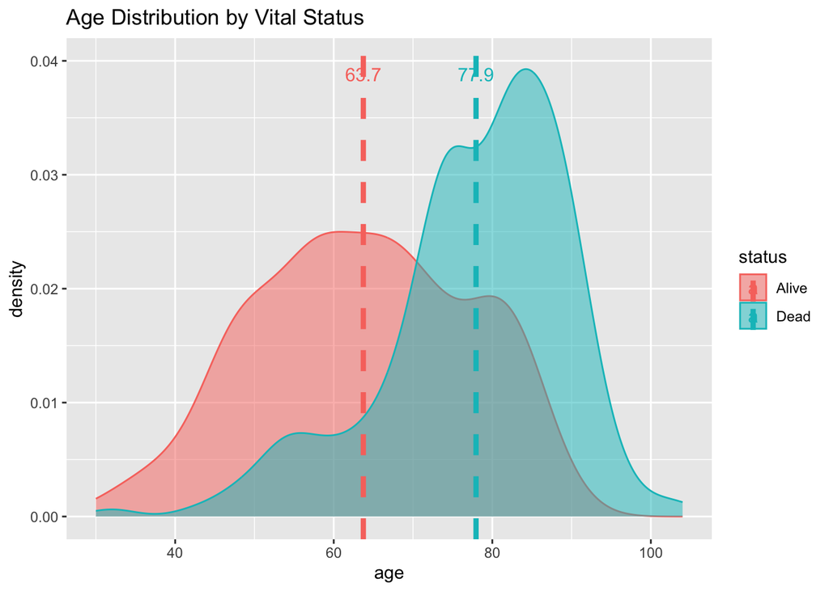

```r
# Calculate mean age for each status group
age_mean <- aggregate(age ~ status, data = df, mean)

# Plot age distribution with mean age lines and labels
ggplot(df, aes(x = age, fill = status, color = status)) +
  geom_density(alpha = 0.5) +
  ggtitle("Age Distribution by Vital Status") +
  geom_vline(data = age_mean, aes(xintercept = age, color = status),
             linetype = "dashed", linewidth = 1.5) +
  geom_text(data = age_mean, aes(x = age, y = 0.04, label = round(age, 1), color = status),
            vjust = 1.5, size = 4) +
  labs(y = "density")
```

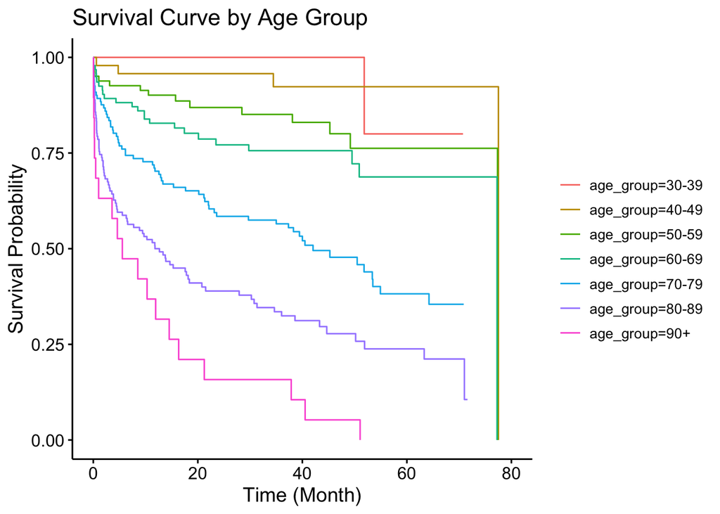

```r
km_age <- survfit(Surv(survival_time, fstat) ~ age_group, data = df) # survival function
ggsurvplot(km_age,
           data = df,
           censor = FALSE,
           size = 0.5,
           legend = "right",
           legend.title = "",
           title = "Survival Curve by Age Group") +
  labs(x = "Time (Month)", y = "Survival Probability") # plot KM curve
```

## Gender

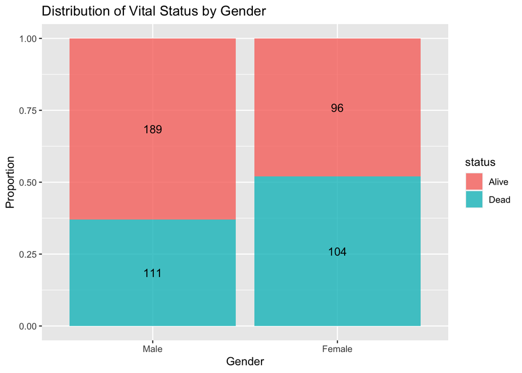

```r
# Calculate counts by gender and status
gender_count <- table(df$gender, df$status)

# Convert table to dataframe
gender_df <- as.data.frame(gender_count)

# Rename columns
colnames(gender_df) <- c("gender", "status", "count")

# Stacked + percent
ggplot(gender_df, aes(fill=status, y=count, x=gender)) +
  geom_bar(position="fill", stat="identity", alpha = 0.8) +
  geom_text(aes(label=count), position=position_fill(vjust=0.5)) +
  ggtitle("Distribution of Vital Status by Gender") +
  xlab("Gender") +
  ylab("Proportion")
```

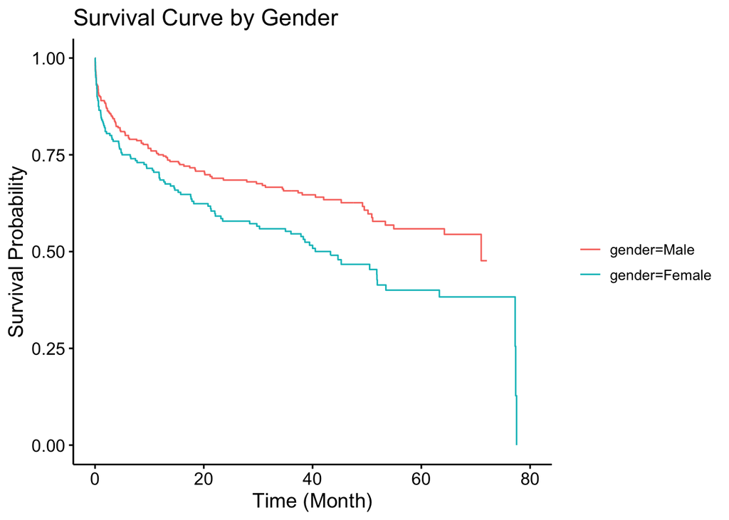

```r
km_gender <- survfit(Surv(survival_time, fstat) ~ gender, data = df) # survival function
ggsurvplot(km_gender,
           data = df,
           censor = FALSE,
           size = 0.5,
           legend = "right",
           legend.title = "",
           title = "Survival Curve by Gender") +
  labs(x = "Time (Month)", y = "Survival Probability") # plot KM curve
```

## Heart Rate

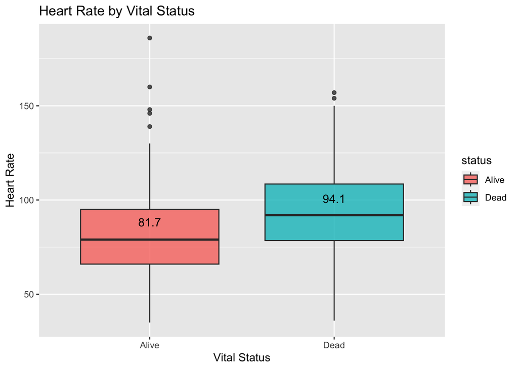

```r
# Calculate mean heart rate for each vital status group
hr_mean <- aggregate(hr ~ status, data = df, mean)

# Create box plot with mean heart rate
ggplot(df, aes(x = status, y = hr, fill = status)) +
  geom_boxplot(alpha = 0.8) +
  geom_text(data = hr_mean, aes(x = status, y = hr, label = round(hr, 1)), size = 4, vjust = -1) +
  ggtitle("Heart Rate by Vital Status") +
  xlab("Vital Status") +
  ylab("Heart Rate")
```

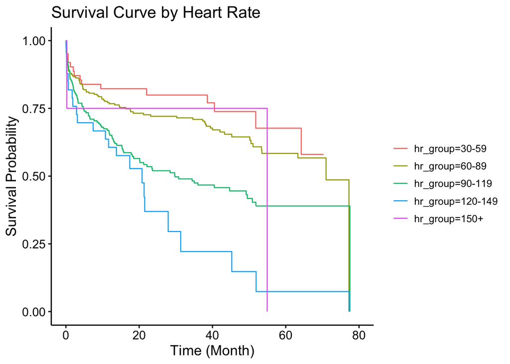

```r
km_hr <- survfit(Surv(survival_time, fstat) ~ hr_group, data = df) # survival function
ggsurvplot(km_hr,
           data = df,
           censor = FALSE,
           size = 0.5,
           legend = "right",
           legend.title = "",
           title = "Survival Curve by Heart Rate") +
  labs(x = "Time (Month)", y = "Survival Probability") # plot KM curve
```

## Blood Pressure

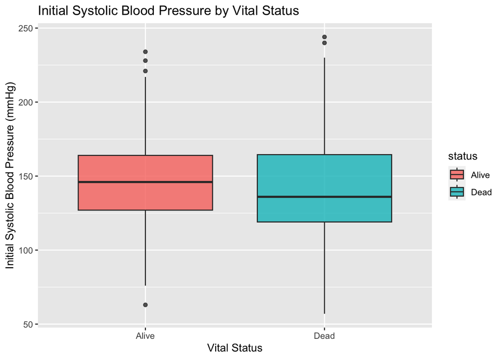

```r
# Systolic Blood Pressure
ggplot(df, aes(x = status, y = sysbp, fill = status)) +
  geom_boxplot(alpha = 0.8) +
  ggtitle("Initial Systolic Blood Pressure by Vital Status") +
  xlab("Vital Status") +
  ylab("Initial Systolic Blood Pressure (mmHg)")
```

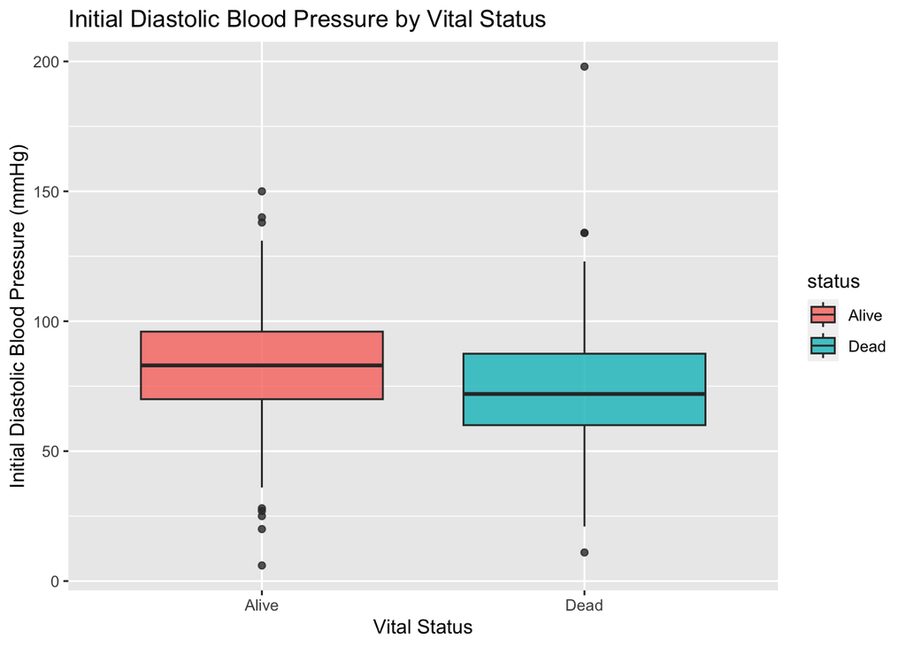

```r
# Diastolic Blood Pressure
ggplot(df, aes(x = status, y = diasbp, fill = status)) +
  geom_boxplot(alpha = 0.8) +
  ggtitle("Initial Diastolic Blood Pressure by Vital Status") +
  xlab("Vital Status") +
  ylab("Initial Diastolic Blood Pressure (mmHg)")
```

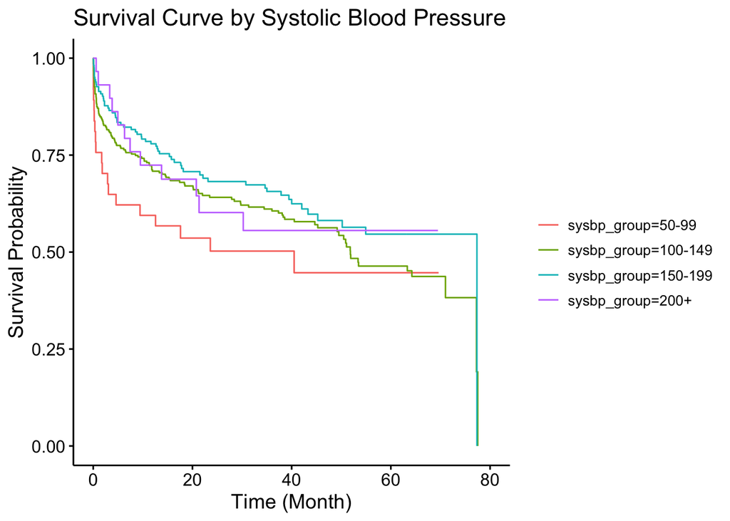

```r
# Systolic Blood Pressure
km_sysbp <- survfit(Surv(survival_time, fstat) ~ sysbp_group, data = df) # survival function
ggsurvplot(km_sysbp,
           data = df,
           censor = FALSE,
           size = 0.5,
           legend = "right",
           legend.title = "",
           title = "Survival Curve by Systolic Blood Pressure") +
  labs(x = "Time (Month)", y = "Survival Probability") # plot KM curve
```

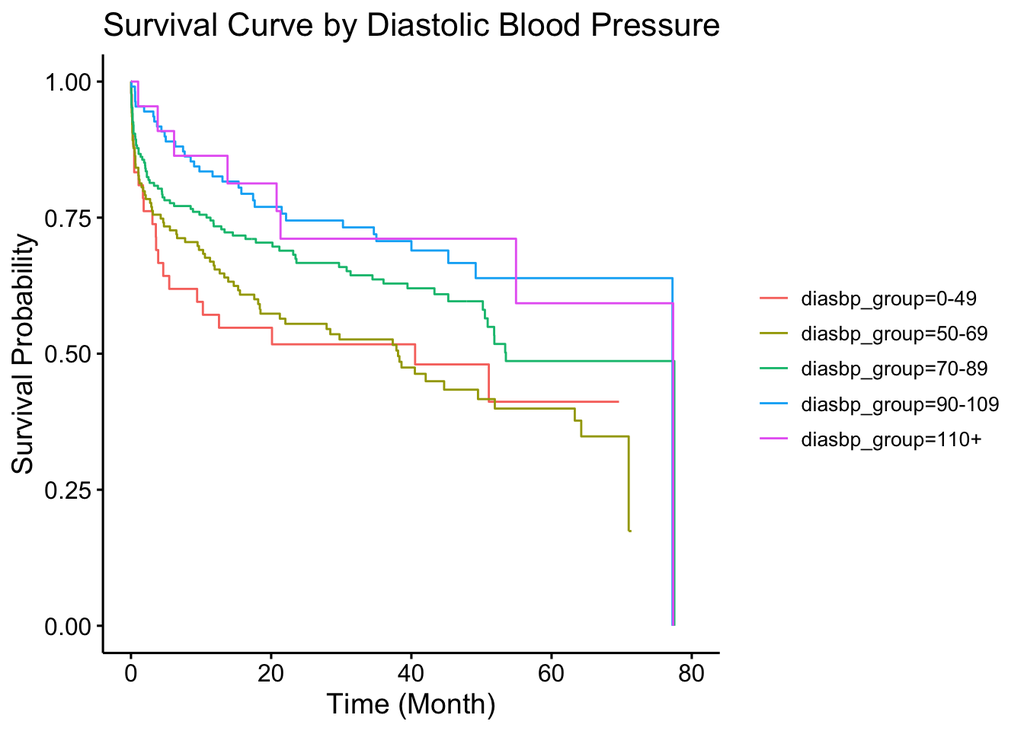

```r
# Diastolic Blood Pressure
km_diasbp <- survfit(Surv(survival_time, fstat) ~ diasbp_group, data = df) # survival function
ggsurvplot(km_diasbp,
           data = df,
           censor = FALSE,
           size = 0.5,
           legend = "right",
           legend.title = "",
           title = "Survival Curve by Diastolic Blood Pressure") +
  labs(x = "Time (Month)", y = "Survival Probability") # plot KM curve
```

## BMI

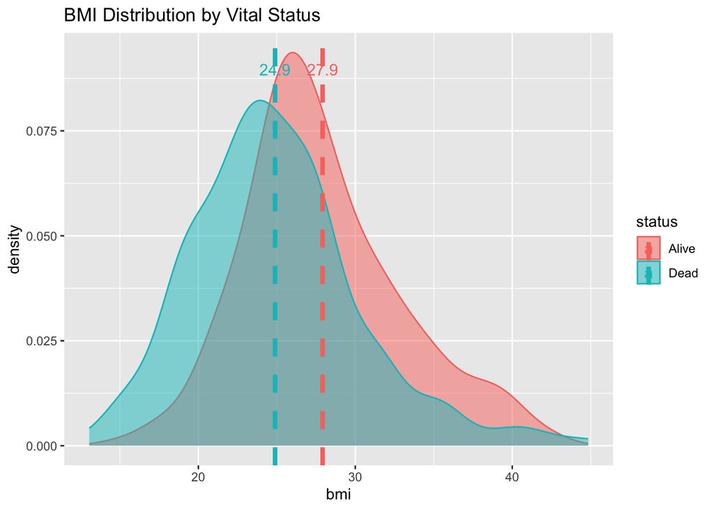

```r
# Calculate mean bmi for each status group
bmi_mean <- aggregate(bmi ~ status, data = df, mean)

# Plot bmi distribution with mean age lines and labels
ggplot(df, aes(x = bmi, fill = status, color = status)) +
  geom_density(alpha = 0.5) +
  ggtitle("BMI Distribution by Vital Status") +
  geom_vline(data = bmi_mean, aes(xintercept = bmi, color = status),
             linetype = "dashed", linewidth = 1.5) +
  geom_text(data = bmi_mean, aes(x = bmi, y = 0.08, label = round(bmi, 1), color = status),
            vjust = -3, size = 4) +
  labs(y = "density")
```

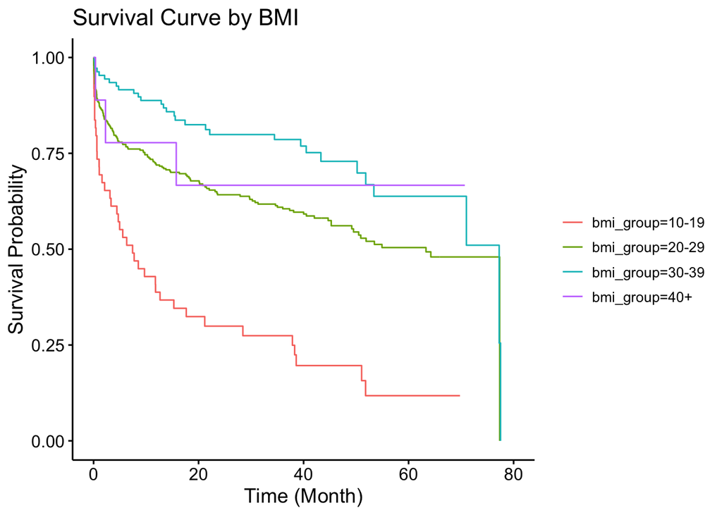

```r
km_bmi <- survfit(Surv(survival_time, fstat) ~ bmi_group, data = df) # survival function
ggsurvplot(km_bmi,
           data = df,
           censor = FALSE,
           size = 0.5,
           legend = "right",
           legend.title = "",
           title = "Survival Curve by BMI") +
  labs(x = "Time (Month)", y = "Survival Probability") # plot KM curve
```

## History of Cardiovascular Disease

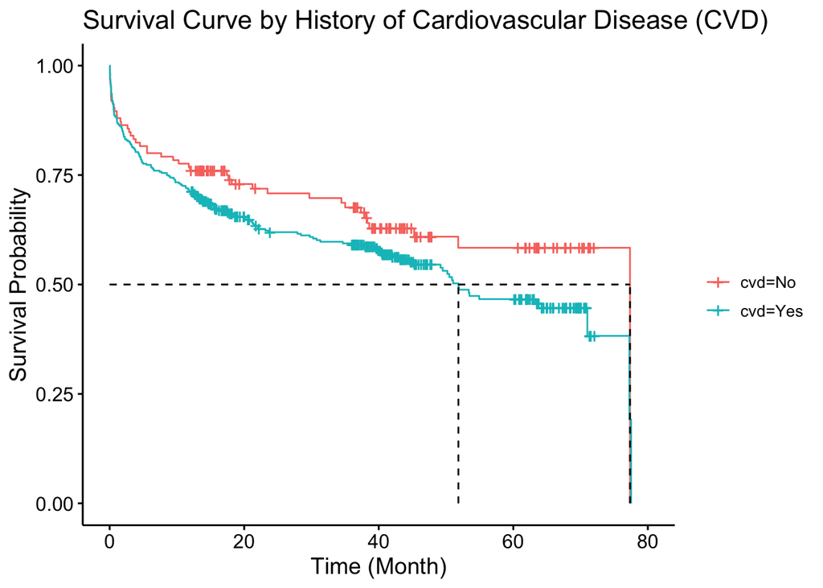

```r
km_cvd <- survfit(Surv(survival_time, fstat) ~ cvd, data = df) # survival function
ggsurvplot(km_cvd,
           data = df,
           surv.median.line = "hv",
           censor = TRUE,
           size = 0.5,
           legend = "right",
           legend.title = "",
           title = "Survival Curve by History of Cardiovascular Disease (CVD)") +
  labs(x = "Time (Month)", y = "Survival Probability") # plot KM curve
```

## Atrial Fibrillation

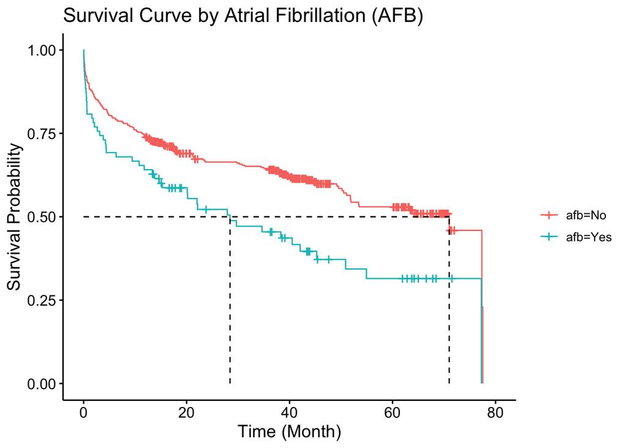

```r
km_afb <- survfit(Surv(survival_time, fstat) ~ afb, data = df) # survival function
ggsurvplot(km_afb,
           data = df,
           surv.median.line = "hv",
           censor = TRUE,
           size = 0.5,
           legend = "right",
           legend.title = "",
           title = "Survival Curve by Atrial Fibrillation (AFB)") +
  labs(x = "Time (Month)", y = "Survival Probability") # plot KM curve
```

## Cardiogenic Shock

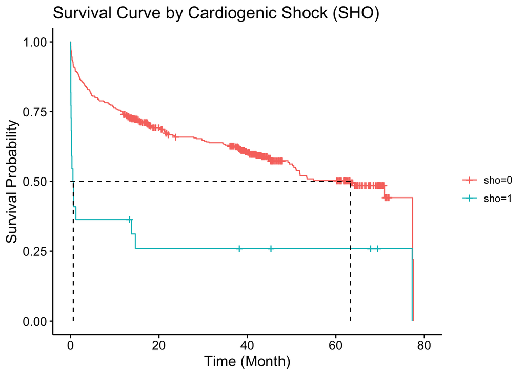

```r
km_sho <- survfit(Surv(survival_time, fstat) ~ sho, data = df) # survival function
ggsurvplot(km_sho,
           data = df,
           surv.median.line = "hv",
           censor = TRUE,
           size = 0.5,
           legend = "right",
           legend.title = "",
           title = "Survival Curve by Cardiogenic Shock (SHO)") +
  labs(x = "Time (Month)", y = "Survival Probability") # plot KM curve
```

## Congestive Heart Complications

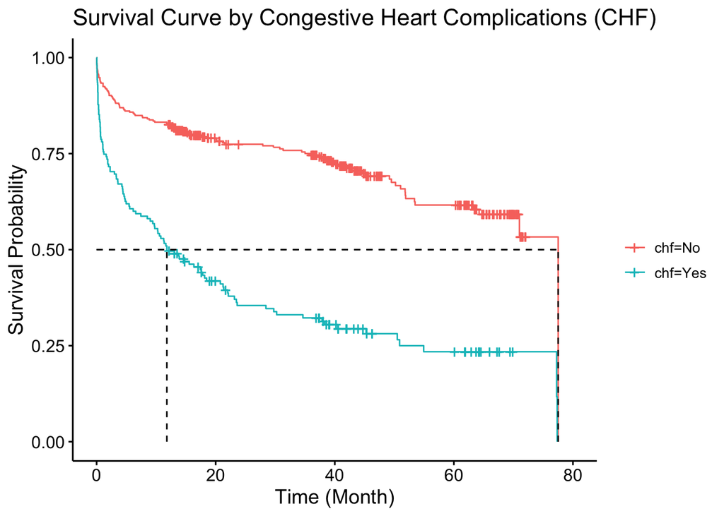

```r
km_chf <- survfit(Surv(survival_time, fstat) ~ chf, data = df) # survival function
ggsurvplot(km_chf,
           data = df,
           surv.median.line = "hv",
           censor = TRUE,
           size = 0.5,
           legend = "right",
           legend.title = "",
           title = "Survival Curve by Congestive Heart Complications (CHF)") +
  labs(x = "Time (Month)", y = "Survival Probability") # plot KM curve
```

## Complete Heart Block

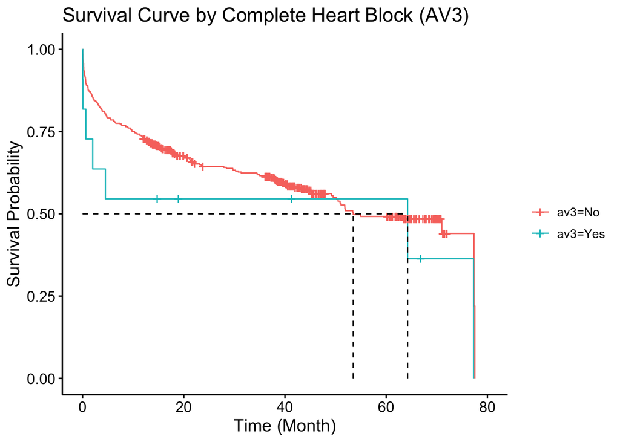

```r
km_av3 <- survfit(Surv(survival_time, fstat) ~ av3, data = df) # survival function
ggsurvplot(km_av3,
           data = df,
           surv.median.line = "hv",
           censor = TRUE,
           size = 0.5,
           legend = "right",
           legend.title = "",
           title = "Survival Curve by Complete Heart Block (AV3)") +
  labs(x = "Time (Month)", y = "Survival Probability") # plot KM curve
```

## MI Order

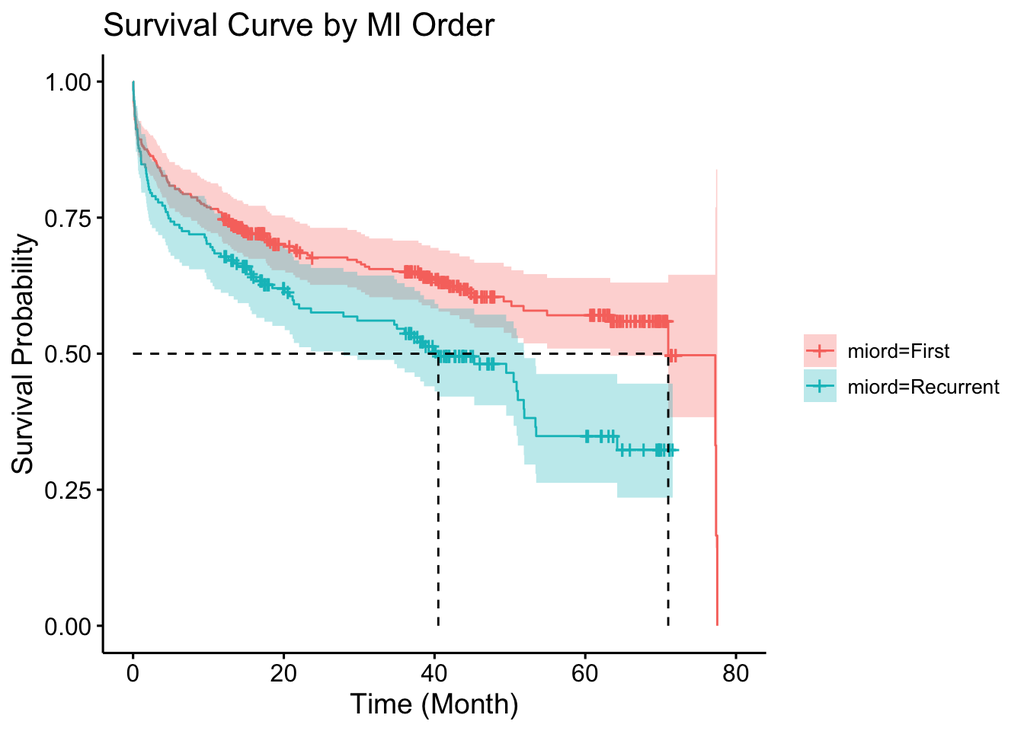

```r
km_miord <- survfit(Surv(survival_time, fstat) ~ miord, data = df) # survival function
ggsurvplot(km_miord,
           data = df,
           surv.median.line = "hv",
           conf.int = TRUE,
           censor = TRUE,
           size = 0.5,
           legend = "right",
           legend.title = "",
           title = "Survival Curve by MI Order") +
  labs(x = "Time (Month)", y = "Survival Probability") # plot KM curve
```

## MI Type

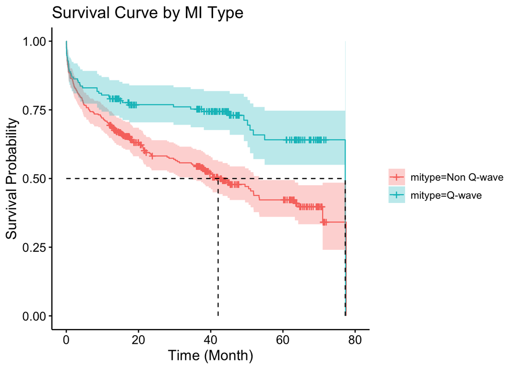

```r
km_mitype <- survfit(Surv(survival_time, fstat) ~ mitype, data = df) # survival function
ggsurvplot(km_mitype,
           data = df,
           surv.median.line = "hv",
           conf.int = TRUE,
           censor = TRUE,
           size = 0.5,
           legend = "right",
           legend.title = "",
           title = "Survival Curve by MI Type") +
  labs(x = "Time (Month)", y = "Survival Probability") # plot KM curve
```

# Cox Proportional Hazards Regression: Survival Time

```r
# Create new dataframe for Cox Regression
df_time <- whas500 %>%
  select(-c(year, disdate, dstat, lenfol, id)) %>%
  mutate(admitdate = as.Date(admitdate, format = "%d-%m-%Y"), # change the date format
         fdate = as.Date(fdate, format = "%d-%m-%Y"), # change the date format
         survival_time = as.numeric(difftime(fdate, admitdate, units = "days")) / 30.42) %>%  # new variable for survival time (month))
  select(-c(admitdate, fdate))

head(df_time)
```

|  | age | gender | hr | sysbp | diasbp | bmi | cvd | afb | sho | chf | av3 | miord | mitype | los | fstat | survival_time |
| --- | --- | --- | --- | --- | --- | --- | --- | --- | --- | --- | --- | --- | --- | --- | --- | --- |
| 1 | 83 | 0 | 89 | 152 | 78 | 25.54051 | 1 | 1 | 0 | 0 | 0 | 1 | 0 | 5 | 0 | 71.59763314 |
| 2 | 49 | 0 | 84 | 120 | 60 | 24.02398 | 1 | 0 | 0 | 0 | 0 | 0 | 1 | 5 | 0 | 71.40039448 |
| 3 | 70 | 1 | 83 | 147 | 88 | 22.14290 | 0 | 0 | 0 | 0 | 0 | 0 | 1 | 5 | 0 | 71.99211045 |
| 4 | 70 | 0 | 65 | 123 | 76 | 26.63187 | 1 | 0 | 0 | 1 | 0 | 0 | 1 | 10 | 1 | 9.76331361 |
| 5 | 70 | 0 | 63 | 135 | 85 | 24.41255 | 1 | 0 | 0 | 0 | 0 | 0 | 1 | 6 | 0 | 70.05259698 |
| 6 | 70 | 0 | 76 | 83 | 54 | 23.24236 | 1 | 0 | 0 | 0 | 1 | 0 | 0 | 1 | 1 | 0.03287311 |

## All Features

```r
# Split the data into a training set and a validation set
set.seed(42)
train <- sample(nrow(df_time), nrow(df_time)*0.7)
train_data <- df_time[train,]
test_data <- df_time[-train,]

# Fit Cox model with all variables
cox_fit <- coxph(Surv(survival_time, fstat) ~ age + gender + hr + sysbp + diasbp + bmi + cvd + afb + sho + chf + av3 + miord + mitype + los, data = train_data)

summary(cox_fit)
```

```
## Call:
## coxph(formula = Surv(survival_time, fstat) ~ age + gender + hr +
##     sysbp + diasbp + bmi + cvd + afb + sho + chf + av3 + miord +
##     mitype + los, data = train_data)
##
##   n= 350, number of events= 154
##
##             coef exp(coef)  se(coef)      z      Pr(>|z|)
## age     0.051354  1.052696  0.008539  6.014 0.00000000181 ***
## gender -0.103218  0.901931  0.174854 -0.590      0.554986
## hr      0.006939  1.006963  0.003654  1.899      0.057552 .
## sysbp   0.003265  1.003270  0.003292  0.992      0.321381
## diasbp -0.012457  0.987620  0.005572 -2.236      0.025371 *
## bmi    -0.031707  0.968791  0.019451 -1.630      0.103084
## cvd    -0.137655  0.871399  0.211514 -0.651      0.515169
## afb    -0.067261  0.934951  0.216898 -0.310      0.756480
## sho     1.019878  2.772857  0.337493  3.022      0.002512 **
## chf     0.707036  2.027971  0.183760  3.848      0.000119 ***
## av3     0.722179  2.058915  0.447632  1.613      0.106672
## miord   0.165255  1.179693  0.185737  0.890      0.373615
## mitype -0.103628  0.901561  0.229382 -0.452      0.651435
## los     0.004169  1.004177  0.018370  0.227      0.820479
## ---
## Signif. codes:  0 '***' 0.001 '**' 0.01 '*' 0.05 '.' 0.1 ' ' 1
##
##        exp(coef) exp(-coef) lower .95 upper .95
## age       1.0527     0.9499    1.0352    1.0705
## gender    0.9019     1.1087    0.6402    1.2706
## hr        1.0070     0.9931    0.9998    1.0142
## sysbp     1.0033     0.9967    0.9968    1.0098
## diasbp    0.9876     1.0125    0.9769    0.9985
## bmi       0.9688     1.0322    0.9326    1.0064
## cvd       0.8714     1.1476    0.5757    1.3190
## afb       0.9350     1.0696    0.6112    1.4303
## sho       2.7729     0.3606    1.4310    5.3728
## chf       2.0280     0.4931    1.4146    2.9072
## av3       2.0589     0.4857    0.8563    4.9507
## miord     1.1797     0.8477    0.8197    1.6977
## mitype    0.9016     1.1092    0.5751    1.4133
## los       1.0042     0.9958    0.9687    1.0410
##
## Concordance= 0.776  (se = 0.019 )
## Likelihood ratio test= 152.2  on 14 df,   p=<0.0000000000000002
## Wald test            = 137.4  on 14 df,   p=<0.0000000000000002
## Score (logrank) test = 154.8  on 14 df,   p=<0.0000000000000002
```

```r
# AIC
aic_all_predictors <- AIC(cox_fit)
aic_all_predictors
```

```
## [1] 1528.679
```

## Feature Selection

```r
# Create an empty model with only the survival object formula
cox_0 <- coxph(Surv(survival_time, fstat) ~ 1, data = train_data)

# Define the full model formula
cox_full <- as.formula("Surv(survival_time, fstat) ~ age + gender + hr + sysbp + diasbp + bmi + cvd + afb + sho + chf + av3 + miord + mitype + los")

# Perform forward selection using step() function
cox_forward <- step(cox_0, direction = "forward", scope = cox_full, method = "loglik")
```

```
## Start:  AIC=1652.83
## Surv(survival_time, fstat) ~ 1
##
##          Df    AIC
## + age     1 1549.2
## + chf     1 1605.8
## + bmi     1 1625.2
## + diasbp  1 1638.3
## + mitype  1 1642.8
## + sho     1 1643.7
## + gender  1 1644.5
## + hr      1 1645.6
## + miord   1 1648.9
## + av3     1 1649.1
## + afb     1 1649.6
## + cvd     1 1651.1
## <none>      1652.8
## + sysbp   1 1654.3
## + los     1 1654.6
##
## Step:  AIC=1549.15
## Surv(survival_time, fstat) ~ age
##
##          Df    AIC
## + chf     1 1526.9
## + sho     1 1541.2
## + hr      1 1545.8
## + diasbp  1 1547.0
## + av3     1 1547.1
## + bmi     1 1548.7
## <none>      1549.2
## + miord   1 1549.3
## + los     1 1550.0
## + afb     1 1550.1
## + sysbp   1 1550.1
## + mitype  1 1550.4
## + gender  1 1550.4
## + cvd     1 1551.1
##
## Step:  AIC=1526.86
```

[output cut: 64 more lines]

```
##
## Step:  AIC=1517.52
## Surv(survival_time, fstat) ~ age + chf + sho + diasbp + hr +
##     bmi
##
##          Df    AIC
## <none>      1517.5
## + av3     1 1517.6
## + miord   1 1518.4
## + sysbp   1 1518.8
## + mitype  1 1519.1
## + gender  1 1519.2
## + afb     1 1519.4
## + cvd     1 1519.5
## + los     1 1519.5
```

```r
# Interpret the final model
summary(cox_forward)
```

```
## Call:
## coxph(formula = Surv(survival_time, fstat) ~ age + chf + sho +
##     diasbp + hr + bmi, data = train_data)
##
##   n= 350, number of events= 154
##
##             coef exp(coef)  se(coef)      z        Pr(>|z|)
## age     0.052809  1.054228  0.008129  6.496 0.0000000000823 ***
## chf     0.720146  2.054734  0.176170  4.088 0.0000435492852 ***
## sho     0.963001  2.619547  0.297335  3.239          0.0012 **
## diasbp -0.009595  0.990451  0.004151 -2.311          0.0208 *
## hr      0.006201  1.006220  0.003423  1.811          0.0701 .
## bmi    -0.030409  0.970049  0.019040 -1.597          0.1102
## ---
## Signif. codes:  0 '***' 0.001 '**' 0.01 '*' 0.05 '.' 0.1 ' ' 1
##
##        exp(coef) exp(-coef) lower .95 upper .95
## age       1.0542     0.9486    1.0376    1.0712
## chf       2.0547     0.4867    1.4548    2.9021
## sho       2.6195     0.3817    1.4626    4.6916
## diasbp    0.9905     1.0096    0.9824    0.9985
## hr        1.0062     0.9938    0.9995    1.0130
## bmi       0.9700     1.0309    0.9345    1.0069
##
## Concordance= 0.773  (se = 0.019 )
## Likelihood ratio test= 147.3  on 6 df,   p=<0.0000000000000002
## Wald test            = 131.6  on 6 df,   p=<0.0000000000000002
## Score (logrank) test = 146.2  on 6 df,   p=<0.0000000000000002
```

## Final Model

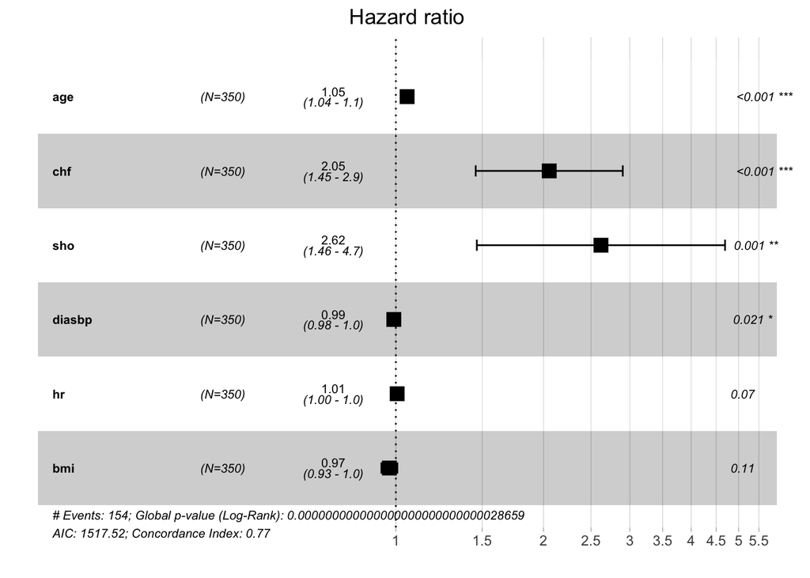

```r
# Plot the hazard ratios and confidence intervals
ggforest(cox_forward, data = train_data)
```

The HR represents the ratio of the hazard of the event occurring in the exposed group to the hazard of the event occurring in the unexposed group. An HR greater than 1 indicates that the exposed group has a higher hazard of the event occurring than the unexposed group. An HR less than 1 indicates that the exposed group has a lower hazard of the event occurring than the unexposed group.

The CI represents the range of values within which the true HR is likely to fall. A wider CI indicates greater uncertainty in the estimate of the HR, whereas a narrower CI indicates greater precision.

In the HR plot, each variable in the model is represented by a horizontal line with a point estimate for the HR and a horizontal line for the CI. If the line crosses the vertical line at 1, the effect is not statistically significant. If the line falls entirely to one side of the vertical line, the effect is statistically significant.

# Logistic Regression: Censor

```r
df_censor <- whas500 %>%
  select(-c(year, disdate, dstat, lenfol, id)) %>%
  mutate(admitdate = as.Date(admitdate, format = "%d-%m-%Y"), # change the date format
         fdate = as.Date(fdate, format = "%d-%m-%Y"), # change the date format
         censor = ifelse(((fdate - admitdate) < 365.25) & fstat == 1, 1, 0),) %>%
  select(-c(admitdate, fdate, fstat))

head(df_censor)
```

|  | age | gender | hr | sysbp | diasbp | bmi | cvd | afb | sho | chf | av3 | miord | mitype | los | censor |
| --- | --- | --- | --- | --- | --- | --- | --- | --- | --- | --- | --- | --- | --- | --- | --- |
| 1 | 83 | 0 | 89 | 152 | 78 | 25.54051 | 1 | 1 | 0 | 0 | 0 | 1 | 0 | 5 | 0 |
| 2 | 49 | 0 | 84 | 120 | 60 | 24.02398 | 1 | 0 | 0 | 0 | 0 | 0 | 1 | 5 | 0 |
| 3 | 70 | 1 | 83 | 147 | 88 | 22.14290 | 0 | 0 | 0 | 0 | 0 | 0 | 1 | 5 | 0 |
| 4 | 70 | 0 | 65 | 123 | 76 | 26.63187 | 1 | 0 | 0 | 1 | 0 | 0 | 1 | 10 | 1 |
| 5 | 70 | 0 | 63 | 135 | 85 | 24.41255 | 1 | 0 | 0 | 0 | 0 | 0 | 1 | 6 | 0 |
| 6 | 70 | 0 | 76 | 83 | 54 | 23.24236 | 1 | 0 | 0 | 0 | 1 | 0 | 0 | 1 | 1 |

## All Features

```r
# Split the data into training and testing sets
set.seed(42)
train <- sample(nrow(df_censor), nrow(df_censor)*0.7)
train_data <- df_censor[train, ]
test_data <- df_censor[-train, ]

# Convert the censor variable to a factor variable
train_data$censor <- factor(train_data$censor)
test_data$censor <- factor(test_data$censor)

# Fit a logistic regression model
glm_full <- glm(censor ~ ., data = train_data, family = "binomial")

summary(glm_full)
```

```
##
## Call:
## glm(formula = censor ~ ., family = "binomial", data = train_data)
##
## Deviance Residuals:
##     Min       1Q   Median       3Q      Max
## -2.1660  -0.6694  -0.3935   0.6699   2.8182
##
## Coefficients:
##              Estimate Std. Error z value   Pr(>|z|)
## (Intercept) -3.589923   1.653027  -2.172   0.029876 *
## age          0.062279   0.013555   4.595 0.00000434 ***
## gender      -0.373391   0.315844  -1.182   0.237126
## hr           0.007596   0.006449   1.178   0.238814
## sysbp        0.007596   0.005723   1.327   0.184394
## diasbp      -0.018952   0.009345  -2.028   0.042567 *
## bmi         -0.098484   0.032973  -2.987   0.002819 **
## cvd          0.005703   0.358020   0.016   0.987291
## afb         -0.321291   0.376321  -0.854   0.393233
## sho          1.031145   0.604828   1.705   0.088222 .
## chf          1.072378   0.310460   3.454   0.000552 ***
## av3          1.394665   0.973248   1.433   0.151858
## miord       -0.225835   0.320220  -0.705   0.480655
## mitype       0.213050   0.350579   0.608   0.543380
## los          0.002544   0.029578   0.086   0.931456
## ---
## Signif. codes:  0 '***' 0.001 '**' 0.01 '*' 0.05 '.' 0.1 ' ' 1
##
## (Dispersion parameter for binomial family taken to be 1)
##
##     Null deviance: 416.94  on 349  degrees of freedom
## Residual deviance: 310.13  on 335  degrees of freedom
## AIC: 340.13
##
## Number of Fisher Scoring iterations: 5
```

```r
# Calculate the predicted probabilities
glm_probs <- predict(glm_full, type = "response")

# Calculate the AUC
glm_auc <- roc(train_data$censor, glm_probs)$auc

# Display the AUC
glm_auc
```

```
## Area under the curve: 0.8307
```

## Feature Selection

```r
# Intercept only
glm_0 <- glm(censor ~ 1, data = train_data, family = "binomial")

# Forward Selection
glm_forward <- step(glm_0,
                    scope = list(lower=formula(glm_0),
                                 upper=formula(glm_full)),
                    direction = "forward")
```

```
## Start:  AIC=418.94
## censor ~ 1
##
##          Df Deviance    AIC
## + age     1   346.19 350.19
## + bmi     1   381.99 385.99
## + chf     1   382.07 386.07
## + diasbp  1   406.54 410.54
## + sho     1   408.04 412.04
## + av3     1   411.23 415.23
## + gender  1   413.08 417.08
## + hr      1   413.95 417.95
## <none>        416.94 418.94
## + mitype  1   415.14 419.14
## + afb     1   415.39 419.39
## + cvd     1   415.39 419.39
## + miord   1   416.25 420.25
## + sysbp   1   416.61 420.61
## + los     1   416.85 420.85
##
## Step:  AIC=350.19
## censor ~ age
##
##          Df Deviance    AIC
## + chf     1   331.37 337.37
## + bmi     1   337.91 343.91
## + sho     1   340.66 346.66
## + av3     1   342.64 348.64
## + diasbp  1   343.09 349.09
## <none>        346.19 350.19
## + hr      1   345.21 351.21
## + los     1   345.69 351.69
## + sysbp   1   345.81 351.81
## + mitype  1   345.82 351.82
## + miord   1   346.17 352.17
## + gender  1   346.18 352.18
## + afb     1   346.18 352.18
## + cvd     1   346.19 352.19
##
## Step:  AIC=337.37
```

[output cut: 49 more lines]

```
##
## Step:  AIC=328.56
## censor ~ age + chf + bmi + sho + av3
##
##          Df Deviance    AIC
## <none>        316.56 328.56
## + diasbp  1   314.83 328.83
## + afb     1   315.72 329.72
## + gender  1   316.01 330.01
## + miord   1   316.34 330.34
## + hr      1   316.35 330.35
## + mitype  1   316.39 330.39
## + los     1   316.52 330.52
## + cvd     1   316.55 330.55
## + sysbp   1   316.55 330.55
```

```r
summary(glm_forward)
```

```
##
## Call:
## glm(formula = censor ~ age + chf + bmi + sho + av3, family = "binomial",
##     data = train_data)
##
## Deviance Residuals:
##     Min       1Q   Median       3Q      Max
## -1.9242  -0.7118  -0.4014   0.7493   2.7925
##
## Coefficients:
##             Estimate Std. Error z value   Pr(>|z|)
## (Intercept) -3.69842    1.40701  -2.629   0.008574 **
## age          0.06239    0.01286   4.851 0.00000123 ***
## chf          1.07385    0.28677   3.745   0.000181 ***
## bmi         -0.09032    0.03112  -2.903   0.003699 **
## sho          0.86067    0.57150   1.506   0.132073
## av3          1.29712    0.94616   1.371   0.170398
## ---
## Signif. codes:  0 '***' 0.001 '**' 0.01 '*' 0.05 '.' 0.1 ' ' 1
##
## (Dispersion parameter for binomial family taken to be 1)
##
##     Null deviance: 416.94  on 349  degrees of freedom
## Residual deviance: 316.56  on 344  degrees of freedom
## AIC: 328.56
##
## Number of Fisher Scoring iterations: 5
```

## Final Model

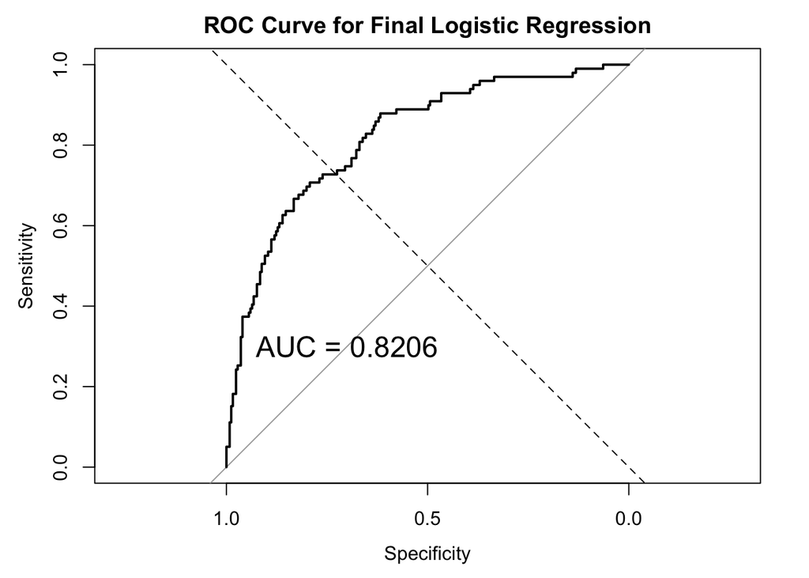

```r
# Calculate the predicted probabilities
glm_forward_probs <- predict(glm_forward, type = "response")

# Calculate the ROC curve
glm_forward_roc <- roc(train_data$censor, glm_forward_probs)

# Calculate AUC
glm_forward_auc <- glm_forward_roc$auc

# Plot the ROC curve with AUC
plot(glm_forward_roc, main = "ROC Curve for Final Logistic Regression")
text(0.7, 0.3, paste("AUC =", round(glm_forward_auc, 4)), cex = 1.5)
abline(a = 0, b = 1, lty = 2)
```

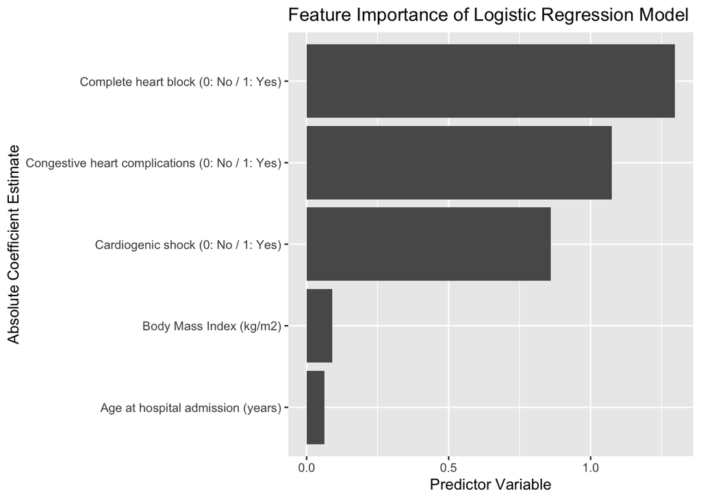

```r
# Extract the coefficients and their standard errors
coef_df <- data.frame(coef = coef(glm_forward), se = summary(glm_forward)$coefficients[, 2])

# Modify the coef_df dataframe
coef_df <- coef_df %>%
  mutate(feature = rownames(coef_df),
         abs_coef = abs(coef)) %>%
  filter(feature != "(Intercept)") %>%
  arrange(abs_coef)
coef_df <- coef_df %>%
  mutate(feature_name = case_when(
    feature == "age" ~ "Age at hospital admission (years)",
    feature == "gender" ~ "Gender (0: Male / 1: Female)",
    feature == "hr" ~ "Initial heart rate (beats per minute)",
    feature == "sysbp" ~ "Initial systolic blood pressure (mmHg)",
    feature == "diasbp" ~ "Initial diastolic blood pressure (mmHg)",
    feature == "bmi" ~ "Body Mass Index (kg/m2)",
    feature == "cvd" ~ "History of cardiovascular disease (0: No / 1: Yes)",
    feature == "afb" ~ "Atrial fibrillation (0: No / 1: Yes)",
    feature == "sho" ~ "Cardiogenic shock (0: No / 1: Yes)",
    feature == "chf" ~ "Congestive heart complications (0: No / 1: Yes)",
    feature == "av3" ~ "Complete heart block (0: No / 1: Yes)",
    feature == "miord" ~ "MI order (0: First / 1: Recurrent)",
    feature == "mitype" ~ "MI type (0: Non-Q-wave / 1: Q-wave)",
    feature == "los" ~ "Length of hospital stay",
    TRUE ~ feature
  ))
rownames(coef_df) <- NULL

coef_df$feature_name <- factor(coef_df$feature_name, levels = coef_df$feature_name)

# Create the bar chart to show feature importance
ggplot(coef_df, aes(feature_name, abs_coef)) +
  geom_col() +
  coord_flip()+
  labs(title = "Feature Importance of Logistic Regression Model",
       x = "Absolute Coefficient Estimate",
       y = "Predictor Variable")
```